# Prosper Loan Data

## by Mahmoud Sallam

## Brief Intro About Prosper

#### - Prosper was founded in 2005 as the first peer-to-peer lending marketplace in the United States.

#### - Prosper has facilitated more than $18 billion in loans to more than 1,100,000 people.

#### - Through Prosper, people can invest in each other in a way that is financially and socially rewarding.

#### - Borrowers apply online for a fixed-rate, fixed-term loan between $2,000 and $40,000.

#### - Individuals and institutions can invest in the loans and earn attractive returns.

#### - Prosper handles all loan servicing on behalf of the matched borrowers and investors.

## We Want To Know

#### - who are the borrowers.

#### - the characteristics of the borrowers.

#### - the purposes that make borrowers take loans.

#### - the variables that affect on the borrower APR.

# Visualization 1

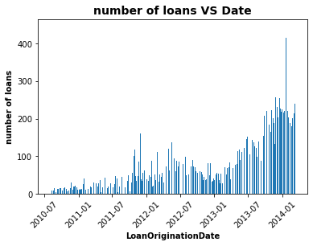

> the huge increase of the loans nuber was in the beginning of 2014

# Visualization 2

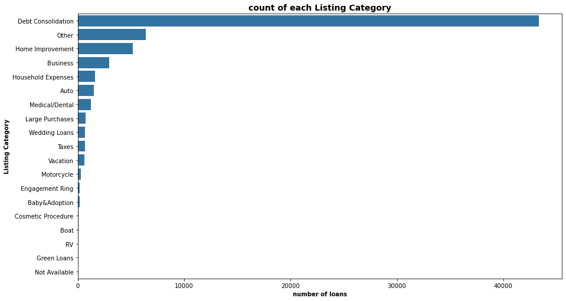

> the debt consolidation takes the biggest number of loans  
> there is increase in taking out a new loan to pay off other liabilities and consumer debts.  
> many peaple couldnt pay their loans so they take another one

# Visualization 3

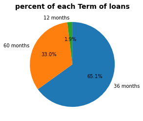

> 65.1% of the loans is for 36 month  
> 33% of the loans is for 60 month  
> 1.9% of the loans is for 12 month

# Visualization 4

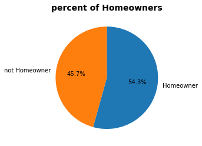

> 54.3% of the Borrowers is Homeowner  
> 45.7% of the Borrowers is not Homeowner

# Visualization 5

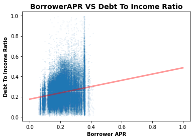

> there is a positive correlation between BorrowerAPR and DebtToIncomeRatio

# Visualization 6

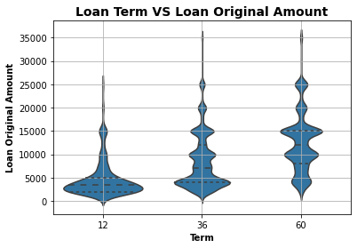

> about 75% of the loans for 12 months are for Amount less than 5000  
> about 75% of the loans for 36 months are for Amount less than 10000  
> about 75% of the loans for 60 months are for Amount less than 15000 with a peak at 15000 as they need more time to pay it back

# Visualization 7

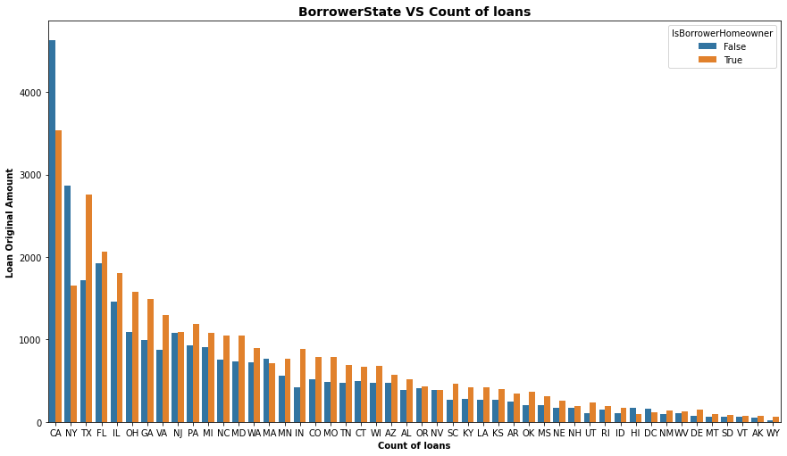

> california has the biggest number of prosper loans then newyork then texas

# Visualization 8

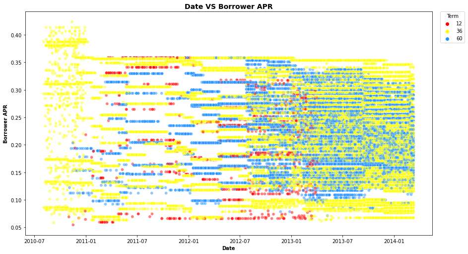

# Visualization 9

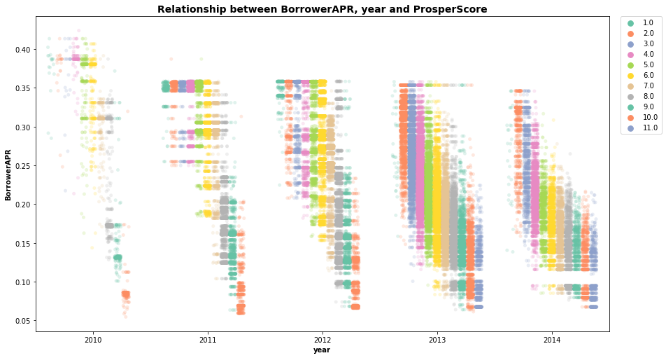

> we can see the increase of the number of loans in 2013 from the density of the points  
> the loans with prosper score of risk are too slight but they appear more in 2011 and 2012  
> even though the prosper score of risk of 2 is the second highest risk, it apears more in 2013